**City College of San Francisco**

MATH 108 - Foundations of Data Science

# Lecture 18: Table Examples

Associated Textbook Sections: [8.5](https://inferentialthinking.com/chapters/08/5/Bike_Sharing_in_the_Bay_Area.html)

**City College of San Francisco**

MATH 108 - Foundations of Data Science

## Outline

- Table Review
- Bike Sharing in SF Bay Area

## Set Up the Notebook

```python
from datascience import *
import numpy as np
%matplotlib inline
import matplotlib.pyplot as plt
plt.style.use('fivethirtyeight')
```

## Table Review

### Important Table Methods

- `t.select(column, ...)` or `t.drop(column, ...)`
- `t.take([row_num, ...])` or `t.exclude([row_num, ...])`
- `t.sort(column, descending=False)`
- `t.where(column, are.condition(...))`
- `t.apply(function_name, column, …)`
- `t.group(column) or t.group(column, function_name)`
- `t.group([column, ...])` or `t.group([column, ...], function_name)`
- `t.pivot(cols, rows)` or `t.pivot(cols, rows, vals, function_name)`
- `t.join(column, other_table, other_table_column)`

## Bike Sharing in SF Bay Area

### Bike Sharing

Hourly bike sharing in the Bay Area began with a pilot program in 2014-2015 that produced a public dataset. The SF Metropolitan Transportation Commission organized an Open Data Challenge in which participants visualized the dataset in interesting ways.

Load the trip data from the csv file `trip.csv`.

```python
trip = Table.read_table('./data/trip.csv')          # Use Table.read_table()
trip.show(3)
```

| Trip ID | Duration | Start Date | Start Station | Start Terminal | End Date | End Station | End Terminal | Bike # | Subscriber Type | Zip Code |
| --- | --- | --- | --- | --- | --- | --- | --- | --- | --- | --- |
| 913460 | 765 | 8/31/2015 23:26 | Harry Bridges Plaza (Ferry Building) | 50 | 8/31/2015 23:39 | San Francisco Caltrain (Townsend at 4th) | 70 | 288 | Subscriber | 2139 |
| 913459 | 1036 | 8/31/2015 23:11 | San Antonio Shopping Center | 31 | 8/31/2015 23:28 | Mountain View City Hall | 27 | 35 | Subscriber | 95032 |
| 913455 | 307 | 8/31/2015 23:13 | Post at Kearny | 47 | 8/31/2015 23:18 | 2nd at South Park | 64 | 468 | Subscriber | 94107 |

... (354149 rows omitted)

#### Exercise 01

Create pivot table for Start Station and End Station.

```python
# this will make a two-way table with Start Stations along the top and End Stations down the side.

trip.pivot(columns='Start Station', rows='End Station')
```

| End Station | 2nd at Folsom | 2nd at South Park | 2nd at Townsend | 5th at Howard | Adobe on Almaden | Arena Green / SAP Center | Beale at Market | Broadway St at Battery St | California Ave Caltrain Station | Castro Street and El Camino Real | Civic Center BART (7th at Market) | Clay at Battery | Commercial at Montgomery | Cowper at University | Davis at Jackson | Embarcadero at Bryant | Embarcadero at Folsom | Embarcadero at Sansome | Embarcadero at Vallejo | Evelyn Park and Ride | Franklin at Maple | Golden Gate at Polk | Grant Avenue at Columbus Avenue | Harry Bridges Plaza (Ferry Building) | Howard at 2nd | Japantown | MLK Library | Market at 10th | Market at 4th | … |
| --- | --- | --- | --- | --- | --- | --- | --- | --- | --- | --- | --- | --- | --- | --- | --- | --- | --- | --- | --- | --- | --- | --- | --- | --- | --- | --- | --- | --- | --- | --- |
| 2nd at Folsom | 87 | 194 | 558 | 108 | 0 | 0 | 41 | 22 | 0 | 0 | 47 | 78 | 55 | 0 | 10 | 78 | 33 | 47 | 17 | 0 | 0 | 11 | 33 | 422 | 55 | 0 | 0 | 170 | 115 | … |
| 2nd at South Park | 299 | 194 | 74 | 183 | 0 | 0 | 210 | 85 | 0 | 0 | 114 | 90 | 164 | 0 | 37 | 60 | 178 | 88 | 116 | 0 | 0 | 58 | 75 | 582 | 503 | 0 | 0 | 140 | 202 | … |
| 2nd at Townsend | 446 | 159 | 280 | 92 | 0 | 0 | 612 | 356 | 0 | 0 | 80 | 333 | 173 | 0 | 391 | 371 | 667 | 540 | 272 | 0 | 0 | 27 | 322 | 2640 | 300 | 0 | 0 | 113 | 241 | … |
| 5th at Howard | 116 | 184 | 153 | 197 | 0 | 0 | 62 | 135 | 0 | 0 | 210 | 77 | 131 | 0 | 33 | 58 | 49 | 178 | 56 | 0 | 0 | 87 | 78 | 380 | 480 | 0 | 0 | 311 | 165 | … |
| Adobe on Almaden | 0 | 0 | 0 | 0 | 29 | 6 | 0 | 0 | 0 | 0 | 0 | 0 | 0 | 0 | 0 | 0 | 0 | 0 | 0 | 0 | 0 | 0 | 0 | 0 | 0 | 17 | 8 | 0 | 0 | … |
| Arena Green / SAP Center | 0 | 0 | 0 | 0 | 9 | 104 | 0 | 0 | 0 | 0 | 0 | 0 | 0 | 0 | 0 | 0 | 0 | 0 | 0 | 1 | 0 | 0 | 0 | 0 | 0 | 17 | 6 | 0 | 0 | … |
| Beale at Market | 127 | 79 | 187 | 64 | 0 | 0 | 114 | 663 | 0 | 0 | 201 | 80 | 101 | 0 | 247 | 178 | 39 | 598 | 168 | 0 | 0 | 54 | 439 | 74 | 72 | 0 | 0 | 286 | 237 | … |
| Broadway St at Battery St | 69 | 92 | 282 | 122 | 0 | 0 | 1026 | 156 | 0 | 0 | 66 | 286 | 231 | 0 | 193 | 201 | 81 | 245 | 37 | 0 | 0 | 7 | 77 | 181 | 49 | 0 | 0 | 35 | 114 | … |
| California Ave Caltrain Station | 0 | 0 | 0 | 0 | 0 | 0 | 0 | 0 | 85 | 1 | 0 | 0 | 0 | 35 | 0 | 0 | 0 | 0 | 0 | 0 | 0 | 0 | 0 | 0 | 0 | 0 | 0 | 0 | 0 | … |
| Castro Street and El Camino Real | 0 | 0 | 0 | 0 | 0 | 0 | 0 | 0 | 0 | 80 | 0 | 0 | 0 | 0 | 0 | 0 | 0 | 0 | 0 | 16 | 0 | 0 | 0 | 0 | 0 | 0 | 0 | 0 | 0 | … |

... (60 rows omitted)

Notice that each value is the number of times the start and end station pair show up in the `trip` table.

```python
trip.where('Start Station', are.equal_to('2nd at Folsom')).where('End Station', are.equal_to('2nd at Folsom')).num_rows
```

```
87
```

#### Exercise 02

Create pivot table showing average duration of the trips between the Start Station and End Station.

```python
# can add numerical info like average time into pivot table using values= (to get the values to operate on)
# and collect= (to give the function to operate with)

trip.pivot(columns='Start Station', rows='End Station',
           values='Duration', collect=np.mean)
```

| End Station | 2nd at Folsom | 2nd at South Park | 2nd at Townsend | 5th at Howard | Adobe on Almaden | Arena Green / SAP Center | Beale at Market | Broadway St at Battery St | California Ave Caltrain Station | Castro Street and El Camino Real | Civic Center BART (7th at Market) | Clay at Battery | Commercial at Montgomery | Cowper at University | Davis at Jackson | Embarcadero at Bryant | Embarcadero at Folsom | Embarcadero at Sansome | Embarcadero at Vallejo | Evelyn Park and Ride | Franklin at Maple | Golden Gate at Polk | Grant Avenue at Columbus Avenue | Harry Bridges Plaza (Ferry Building) | Howard at 2nd | Japantown | MLK Library | Market at 10th | Market at 4th | … |
| --- | --- | --- | --- | --- | --- | --- | --- | --- | --- | --- | --- | --- | --- | --- | --- | --- | --- | --- | --- | --- | --- | --- | --- | --- | --- | --- | --- | --- | --- | --- |
| 2nd at Folsom | 3126.6 | 393.552 | 334.699 | 445.546 | 0 | 0 | 595.537 | 839.636 | 0 | 0 | 790.064 | 516.897 | 588.491 | 0 | 1761.4 | 433.744 | 533.061 | 2260.81 | 9999.29 | 0 | 0 | 825 | 1612.61 | 2456.6 | 568.745 | 0 | 0 | 747.494 | 460.217 | … |
| 2nd at South Park | 235.729 | 1671.71 | 316.23 | 542.295 | 0 | 0 | 529.043 | 715.247 | 0 | 0 | 926.43 | 680.189 | 670.073 | 0 | 640.081 | 567.283 | 404.27 | 1134.38 | 648.948 | 0 | 0 | 754.362 | 993.987 | 873.881 | 240.62 | 0 | 0 | 841.8 | 575.401 | … |
| 2nd at Townsend | 434.341 | 583.755 | 2636.55 | 655.196 | 0 | 0 | 689.255 | 780.067 | 0 | 0 | 846.888 | 846.514 | 850.543 | 0 | 775.514 | 483.728 | 597.793 | 1239.13 | 1870.3 | 0 | 0 | 1070.59 | 981.578 | 645.451 | 520.583 | 0 | 0 | 4071.93 | 1134.56 | … |
| 5th at Howard | 501.259 | 999.304 | 1660.5 | 6787.49 | 0 | 0 | 973.79 | 883.681 | 0 | 0 | 455.276 | 692.623 | 718.435 | 0 | 1161.85 | 747.672 | 613.49 | 1262.89 | 2632.8 | 0 | 0 | 520.207 | 834.692 | 767.9 | 391.229 | 0 | 0 | 702.511 | 662.145 | … |
| Adobe on Almaden | 0 | 0 | 0 | 0 | 3778.86 | 3475.33 | 0 | 0 | 0 | 0 | 0 | 0 | 0 | 0 | 0 | 0 | 0 | 0 | 0 | 0 | 0 | 0 | 0 | 0 | 0 | 942.176 | 2026.25 | 0 | 0 | … |
| Arena Green / SAP Center | 0 | 0 | 0 | 0 | 1506.11 | 4824.14 | 0 | 0 | 0 | 0 | 0 | 0 | 0 | 0 | 0 | 0 | 0 | 0 | 0 | 27409 | 0 | 0 | 0 | 0 | 0 | 1037.53 | 1692.33 | 0 | 0 | … |
| Beale at Market | 360.701 | 603.873 | 788.027 | 916.781 | 0 | 0 | 6228.8 | 534.03 | 0 | 0 | 627.423 | 637.938 | 303.168 | 0 | 232.777 | 441.483 | 379.897 | 610.12 | 450.494 | 0 | 0 | 697.074 | 480.713 | 2682.78 | 329.5 | 0 | 0 | 731.175 | 409.882 | … |
| Broadway St at Battery St | 697.913 | 865.663 | 744.826 | 1121.39 | 0 | 0 | 377.225 | 3226.06 | 0 | 0 | 1155.76 | 296.434 | 543.671 | 0 | 212.85 | 619.159 | 582.654 | 868.592 | 1090.16 | 0 | 0 | 1565.86 | 1147.74 | 741.917 | 600.939 | 0 | 0 | 2032.66 | 1217.94 | … |
| California Ave Caltrain Station | 0 | 0 | 0 | 0 | 0 | 0 | 0 | 0 | 11524.9 | 1645 | 0 | 0 | 0 | 4262.8 | 0 | 0 | 0 | 0 | 0 | 0 | 0 | 0 | 0 | 0 | 0 | 0 | 0 | 0 | 0 | … |
| Castro Street and El Camino Real | 0 | 0 | 0 | 0 | 0 | 0 | 0 | 0 | 0 | 7623.38 | 0 | 0 | 0 | 0 | 0 | 0 | 0 | 0 | 0 | 4091.38 | 0 | 0 | 0 | 0 | 0 | 0 | 0 | 0 | 0 | … |

... (60 rows omitted)

```python
# grouping to classify rentals by Start Station, End Station and subscriber type with average rental time in table

trip_reduced = trip.select('Start Station', 'End Station',
                           'Subscriber Type', 'Duration')
trip_reduced.group(['Start Station', 'End Station',
                    'Subscriber Type'], np.mean)
```

| Start Station | End Station | Subscriber Type | Duration mean |
| --- | --- | --- | --- |
| 2nd at Folsom | 2nd at Folsom | Customer | 4797.67 |
| 2nd at Folsom | 2nd at Folsom | Subscriber | 1336.17 |
| 2nd at Folsom | 2nd at South Park | Customer | 563.917 |
| 2nd at Folsom | 2nd at South Park | Subscriber | 222.007 |
| 2nd at Folsom | 2nd at Townsend | Customer | 2027.72 |
| 2nd at Folsom | 2nd at Townsend | Subscriber | 311.181 |
| 2nd at Folsom | 5th at Howard | Customer | 1166.73 |
| 2nd at Folsom | 5th at Howard | Subscriber | 431.543 |
| 2nd at Folsom | Beale at Market | Customer | 473.5 |
| 2nd at Folsom | Beale at Market | Subscriber | 355.107 |

... (3267 rows omitted)

### 🛑 Clear Memory to Continue 🛑

- This data set is very large, so it takes up a lot of memory.
- Run the following cell to clear the memory (`%reset -f`) and continue.
- The rest of the notebook should be able to be run with the available memory.

```python
%reset -f

# Re-Import Tools
from datascience import *
import numpy as np
%matplotlib inline
import matplotlib.pyplot as plt
plt.style.use('fivethirtyeight')

# Re-Load Data
trip = Table.read_table('./data/trip.csv')
```

### Distribution of Duration Values

Notice what happens when you try to visualize the distributions of trip duration values.

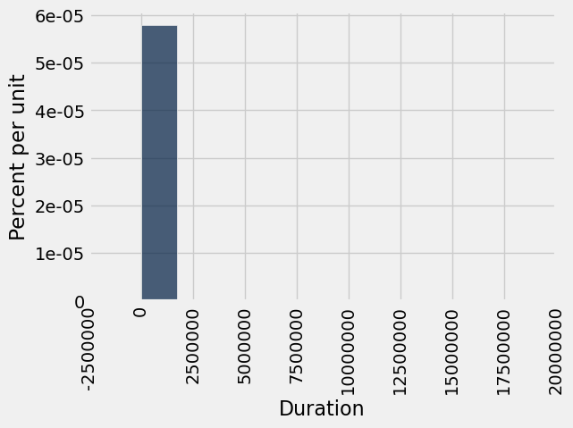

```python
trip.hist('Duration')
```

```python
np.max(trip.column('Duration'))    # visual shows the entire range but MOST of the data is in the one bar
```

```
17270400
```

#### Exercise 03

Create histogram with bins ranging from 0 to 1800 in increments of 250.

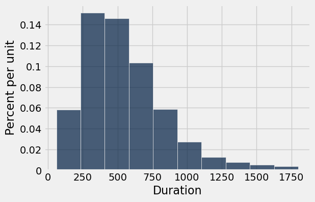

```python
commute = trip.where('Duration', are.below(1800))   # free trips are under 1800 seconds (30 mins)
commute.hist('Duration')
```

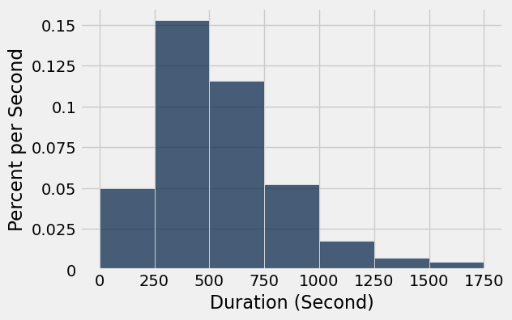

```python
commute.hist('Duration', bins=np.arange(0, 1800, 250), unit='Second')
```

#### Exercise 04

What percent of people have a ride duration between 250 and 500 seconds, not including 500.

```python
num_between_250_and_500 = commute.where('Duration', are.between(250, 500)).num_rows    # numerator
num_between_250_and_500
```

```
129079
```

```python
commute.num_rows       # denominator
```

```
338343
```

```python
(num_between_250_and_500 / commute.num_rows) *100
```

```
38.150338561755376
```

How do you see this in the histogram?

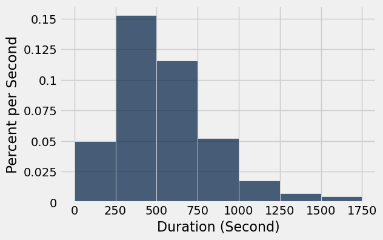

```python
# here is the histogram again

commute.hist('Duration', bins=np.arange(0, 1800, 250), unit='Second')
```

The height of the [250, 500) bar is approximately 0.155, and the width of the bar is 250.

```python
250 * 0.155
```

```
38.75
```

#### Exercise 05

Create histogram with more fine grained bins to see if there are any gaps in the duration values.

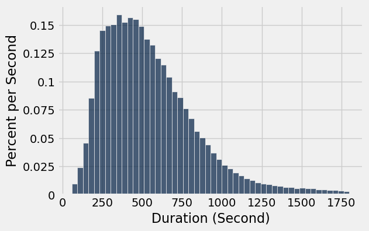

```python
commute.hist('Duration', bins=50, unit='Second')       # bins = 50 gives the width of the bins
```

### Start and End Stations

#### Exercise 06

What is the most common start station?

```python
starts = commute.group('Start Station').sort('count', descending=True)
starts

# starts.row(0).item(0)
```

| Start Station | count |
| --- | --- |
| San Francisco Caltrain (Townsend at 4th) | 25858 |
| San Francisco Caltrain 2 (330 Townsend) | 21523 |
| Harry Bridges Plaza (Ferry Building) | 15543 |
| Temporary Transbay Terminal (Howard at Beale) | 14298 |
| 2nd at Townsend | 13674 |
| Townsend at 7th | 13579 |
| Steuart at Market | 13215 |
| Embarcadero at Sansome | 12842 |
| Market at 10th | 11523 |
| Market at Sansome | 11023 |

... (60 rows omitted)

What is the average duration of trips between stations?

```python
# did similar thing above. Now we are looking at all trips below 1800 secs.

commute.pivot('Start Station', 'End Station', values='Duration', collect=np.average)


# OR np.mean(commute.column('Duration'))
```

| End Station | 2nd at Folsom | 2nd at South Park | 2nd at Townsend | 5th at Howard | Adobe on Almaden | Arena Green / SAP Center | Beale at Market | Broadway St at Battery St | California Ave Caltrain Station | Castro Street and El Camino Real | Civic Center BART (7th at Market) | Clay at Battery | Commercial at Montgomery | Cowper at University | Davis at Jackson | Embarcadero at Bryant | Embarcadero at Folsom | Embarcadero at Sansome | Embarcadero at Vallejo | Evelyn Park and Ride | Franklin at Maple | Golden Gate at Polk | Grant Avenue at Columbus Avenue | Harry Bridges Plaza (Ferry Building) | Howard at 2nd | Japantown | MLK Library | Market at 10th | Market at 4th | … |
| --- | --- | --- | --- | --- | --- | --- | --- | --- | --- | --- | --- | --- | --- | --- | --- | --- | --- | --- | --- | --- | --- | --- | --- | --- | --- | --- | --- | --- | --- | --- |
| 2nd at Folsom | 702.13 | 253.874 | 309.087 | 418.065 | 0 | 0 | 424.15 | 740.714 | 0 | 0 | 668.886 | 516.897 | 495.519 | 0 | 862.889 | 388.117 | 493.469 | 1114.71 | 818.429 | 0 | 0 | 825 | 662.933 | 500.44 | 254.245 | 0 | 0 | 728.627 | 435.947 | … |
| 2nd at South Park | 196.085 | 618.116 | 237.366 | 507.394 | 0 | 0 | 450.279 | 715.247 | 0 | 0 | 900.679 | 589.368 | 612.456 | 0 | 640.081 | 317.625 | 404.27 | 940.253 | 648.948 | 0 | 0 | 732.632 | 815.671 | 501.608 | 230.486 | 0 | 0 | 834.396 | 513.307 | … |
| 2nd at Townsend | 293.874 | 281.344 | 787.314 | 655.196 | 0 | 0 | 531.243 | 759.451 | 0 | 0 | 846.888 | 773.72 | 803.345 | 0 | 691.054 | 363.294 | 465.685 | 926.796 | 819.772 | 0 | 0 | 1070.59 | 919.073 | 609.987 | 371.105 | 0 | 0 | 877.591 | 731.92 | … |
| 5th at Howard | 381.274 | 573.729 | 613.514 | 718.096 | 0 | 0 | 611.797 | 808.077 | 0 | 0 | 379.35 | 668.697 | 542.512 | 0 | 730.4 | 666.965 | 613.49 | 1056.59 | 952.167 | 0 | 0 | 469.741 | 834.692 | 676.55 | 281.975 | 0 | 0 | 449.548 | 295.297 | … |
| Adobe on Almaden | 0 | 0 | 0 | 0 | 462 | 583.5 | 0 | 0 | 0 | 0 | 0 | 0 | 0 | 0 | 0 | 0 | 0 | 0 | 0 | 0 | 0 | 0 | 0 | 0 | 0 | 942.176 | 616 | 0 | 0 | … |
| Arena Green / SAP Center | 0 | 0 | 0 | 0 | 540.286 | 948.844 | 0 | 0 | 0 | 0 | 0 | 0 | 0 | 0 | 0 | 0 | 0 | 0 | 0 | 0 | 0 | 0 | 0 | 0 | 0 | 955.312 | 952.6 | 0 | 0 | … |
| Beale at Market | 360.701 | 603.873 | 685.934 | 625 | 0 | 0 | 720.932 | 282.033 | 0 | 0 | 627.423 | 273.973 | 303.168 | 0 | 232.777 | 441.483 | 300.5 | 498.2 | 352.467 | 0 | 0 | 697.074 | 416.986 | 465.877 | 329.5 | 0 | 0 | 731.175 | 386.292 | … |
| Broadway St at Battery St | 613.672 | 826.899 | 719.695 | 931.891 | 0 | 0 | 331.727 | 688.682 | 0 | 0 | 942.629 | 240.929 | 245.23 | 0 | 190.906 | 576.172 | 503.241 | 369.61 | 403.314 | 0 | 0 | 1213.2 | 364.543 | 436.101 | 600.939 | 0 | 0 | 1068.12 | 629.866 | … |
| California Ave Caltrain Station | 0 | 0 | 0 | 0 | 0 | 0 | 0 | 0 | 898.553 | 1645 | 0 | 0 | 0 | 977.552 | 0 | 0 | 0 | 0 | 0 | 0 | 0 | 0 | 0 | 0 | 0 | 0 | 0 | 0 | 0 | … |
| Castro Street and El Camino Real | 0 | 0 | 0 | 0 | 0 | 0 | 0 | 0 | 0 | 817.5 | 0 | 0 | 0 | 0 | 0 | 0 | 0 | 0 | 0 | 747.214 | 0 | 0 | 0 | 0 | 0 | 0 | 0 | 0 | 0 | … |

... (60 rows omitted)

### Fastest Trips between Stations

#### Exercise 07

What is the fastest trip ever between each pair of stations?

```python
# first. pare down original data set to pertinent columns

duration = trip.select('Start Station', 'End Station', 'Duration')
duration
```

| Start Station | End Station | Duration |
| --- | --- | --- |
| Harry Bridges Plaza (Ferry Building) | San Francisco Caltrain (Townsend at 4th) | 765 |
| San Antonio Shopping Center | Mountain View City Hall | 1036 |
| Post at Kearny | 2nd at South Park | 307 |
| San Jose City Hall | San Salvador at 1st | 409 |
| Embarcadero at Folsom | Embarcadero at Sansome | 789 |
| Yerba Buena Center of the Arts (3rd @ Howard) | San Francisco Caltrain (Townsend at 4th) | 293 |
| Embarcadero at Folsom | Embarcadero at Sansome | 896 |
| Embarcadero at Sansome | Steuart at Market | 255 |
| Beale at Market | Temporary Transbay Terminal (Howard at Beale) | 126 |
| Post at Kearny | South Van Ness at Market | 932 |

... (354142 rows omitted)

```python
# Next, group and sort.

shortest = duration.group(['Start Station', 'End Station'], min).sort('Duration min')
shortest.show(10)
```

| Start Station | End Station | Duration min |
| --- | --- | --- |
| 2nd at South Park | 2nd at South Park | 60 |
| 2nd at Townsend | 2nd at Townsend | 60 |
| Beale at Market | Beale at Market | 60 |
| Civic Center BART (7th at Market) | Civic Center BART (7th at Market) | 60 |
| Embarcadero at Folsom | Embarcadero at Folsom | 60 |
| Embarcadero at Sansome | Embarcadero at Sansome | 60 |
| Golden Gate at Polk | Golden Gate at Polk | 60 |
| Harry Bridges Plaza (Ferry Building) | Harry Bridges Plaza (Ferry Building) | 60 |
| Howard at 2nd | 2nd at South Park | 60 |
| Howard at 2nd | Howard at 2nd | 60 |

... (1682 rows omitted)

#### Exercise 08

What are the 5 stations closest to Civic Center BART by minimum trip time.

```python
# filter out Civic Center starts

from_cc = shortest.where('Start Station', are.containing('Civic Center BART'))
from_cc.take(np.arange(5))
```

| Start Station | End Station | Duration min |
| --- | --- | --- |
| Civic Center BART (7th at Market) | Civic Center BART (7th at Market) | 60 |
| Civic Center BART (7th at Market) | Powell Street BART | 97 |
| Civic Center BART (7th at Market) | Market at 10th | 104 |
| Civic Center BART (7th at Market) | Golden Gate at Polk | 141 |
| Civic Center BART (7th at Market) | San Francisco City Hall | 151 |

```python
# filter out Civic Center ends

to_cc = shortest.where('End Station', are.containing('Civic Center BART'))
to_cc.take(np.arange(5))
```

| Start Station | End Station | Duration min |
| --- | --- | --- |
| Civic Center BART (7th at Market) | Civic Center BART (7th at Market) | 60 |
| Market at 10th | Civic Center BART (7th at Market) | 98 |
| Powell Street BART | Civic Center BART (7th at Market) | 102 |
| Golden Gate at Polk | Civic Center BART (7th at Market) | 104 |
| San Francisco City Hall | Civic Center BART (7th at Market) | 146 |